# Statistical Inference project part 2

Abdelrahman Elsehaily

September 29, 2017

## 1.Introduction

The goal of this document is to provide basic summary of “ToothGrowth” dataset in R and usin t-test and confidence intervals try to answer two main questions:  
1.Is there significant difference in the lenght with the two delivery methods?  
2.Is there significant difference in the lenght with different doses?

## 2.Analysis

Loading ggplot for plotting the data

```r
library("ggplot2")
```

### 2.1.Summary of the data

The column of the dataset

```r
summary(ToothGrowth)
```

```
##       len        supp         dose
##  Min.   : 4.20   OJ:30   Min.   :0.500
##  1st Qu.:13.07   VC:30   1st Qu.:0.500
##  Median :19.25           Median :1.000
##  Mean   :18.81           Mean   :1.167
##  3rd Qu.:25.27           3rd Qu.:2.000
##  Max.   :33.90           Max.   :2.000
```

The first rows of the data set

```r
head(ToothGrowth)
```

```
##    len supp dose
## 1  4.2   VC  0.5
## 2 11.5   VC  0.5
## 3  7.3   VC  0.5
## 4  5.8   VC  0.5
## 5  6.4   VC  0.5
## 6 10.0   VC  0.5
```

Using boxplot I plotted the dataset as y-axis is the lenght of odontoblasts and x-axis is the doses.

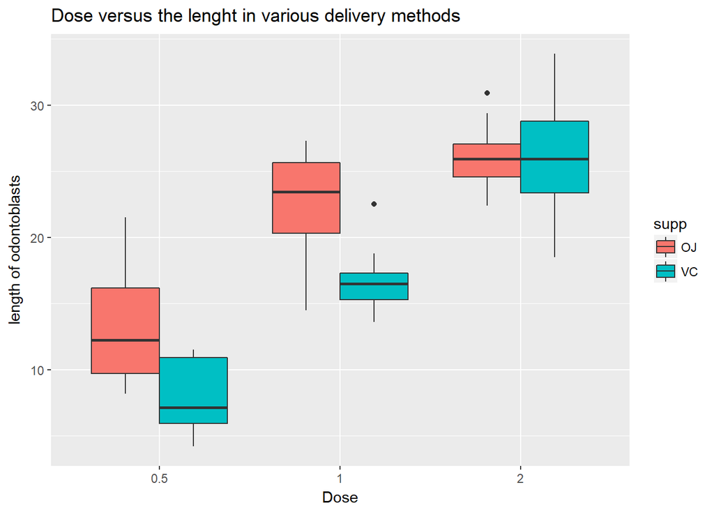

```r
ggplot(data=ToothGrowth,aes(x=as.factor(dose),y=len,fill=supp))+geom_boxplot()+ggtitle("Dose versus the lenght in various delivery methods")+xlab("Dose")+ylab("length of odontoblasts")
```

## 2.2.what is the effect of supply method(orange juice vs ascorbic acid)?

We wanna see if there is significant difference between the two delivery methods(supp) so our hypothesis I think is the following:  
H0: M0-Ma=0  
Ha: M0-Ma!=0  
as M0,Ma are the means of the deliveries method.

```r
t.test(len~supp,data=ToothGrowth)
```

```
##
##  Welch Two Sample t-test
##
## data:  len by supp
## t = 1.9153, df = 55.309, p-value = 0.06063
## alternative hypothesis: true difference in means is not equal to 0
## 95 percent confidence interval:
##  -0.1710156  7.5710156
## sample estimates:
## mean in group OJ mean in group VC
##         20.66333         16.96333
```

The p-value is not significant as the p-value >0.025 (considering the two sided) We fail to reject the null hypothesis H0.

## 2.3.Does the dose affet the length?

```r
t.test(len~dose,data=ToothGrowth[ToothGrowth$dose ==0.5 | ToothGrowth$dose ==1,])
```

```
##
##  Welch Two Sample t-test
##
## data:  len by dose
## t = -6.4766, df = 37.986, p-value = 1.268e-07
## alternative hypothesis: true difference in means is not equal to 0
## 95 percent confidence interval:
##  -11.983781  -6.276219
## sample estimates:
## mean in group 0.5   mean in group 1
##            10.605            19.735
```

```r
t.test(len~dose,data=ToothGrowth[ToothGrowth$dose ==1 | ToothGrowth$dose ==2,])
```

```
##
##  Welch Two Sample t-test
##
## data:  len by dose
## t = -4.9005, df = 37.101, p-value = 1.906e-05
## alternative hypothesis: true difference in means is not equal to 0
## 95 percent confidence interval:
##  -8.996481 -3.733519
## sample estimates:
## mean in group 1 mean in group 2
##          19.735          26.100
```

as the p-value is lower thean 0.05, so the there is siginficant difference of the length so we reject the null hypothesis.

## 3.conslusion

There’s no significant differnce in the lenght of odontoblasts with the different delivery methods.  
Ther’s significance increase in the length as the dose increase.